# Non-linear Regression

Nina van Gerwen (1860852)

2022-10-24

## Prediction plot

```r
library(MASS)
library(splines)
library(ISLR)
library(tidyverse)
set.seed(45)
```

### 1) Creating a prediction plot function

```r
pred_plot <- function(lm_mod){
  x1 <- seq(min(Boston$lstat), max(Boston$lstat), length.out = 1000)
  y1 <- predict(lm_mod, newdata = data.frame(lstat = x1))

  Boston %>%
    ggplot(aes(x = lstat, y = medv), data = .) +
    geom_point() +
    geom_line(data = data.frame(lstat = x1, medv = y1), col = "red") +
    theme_minimal()
}
```

### 2) Testing the function

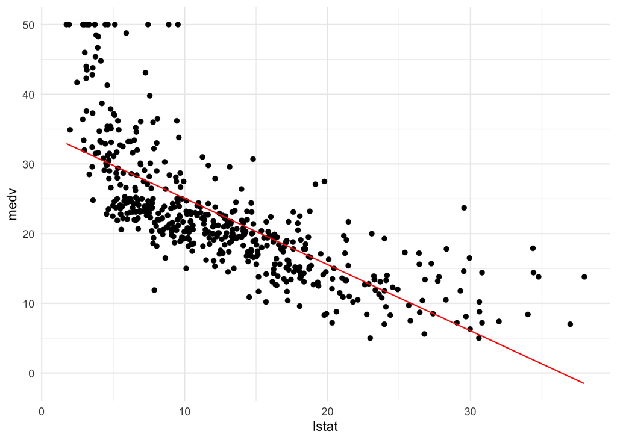

```r
lin_mod <- lm(medv ~ lstat, data = Boston)
pred_plot(lin_mod)
```

The plot works, as for anything out of the ordinary: the predictions for medv go negative at lstat values beyond 35, which should not be possible (as value is always positive).

## Polynomial regression

### 3) Creating a polynomial regression

```r
pn3_mod <- lm(medv ~ I(lstat) + I(lstat^2) + I(lstat^3), data = Boston)

pred_plot(pn3_mod)
```

[output not shown]

### 4) Poly function

The degree argument states the degree of the polynomial. So if it is 3, then you will receive a polynomial to the third order (i.e., $x, x^2, x^3$). If raw = TRUE, you will receive the raw polynomials and not the orthogonal polynomials. This means that they will correlate with one another and multicollinearity might then be an issue.

### 5) Poly function in lm function

```r
pn3_2_mod <- lm(medv ~ poly(lstat, degree = 3, raw = TRUE), data = Boston)

pred_plot(pn3_2_mod)
```

[output not shown]

```r
pn3_3_mod <- lm(medv ~ poly(lstat, degree = 3, raw = FALSE), data = Boston)

pred_plot(pn3_3_mod)
```

[output not shown]

## Piecewise regression

### 6) Creating a piecewise regression

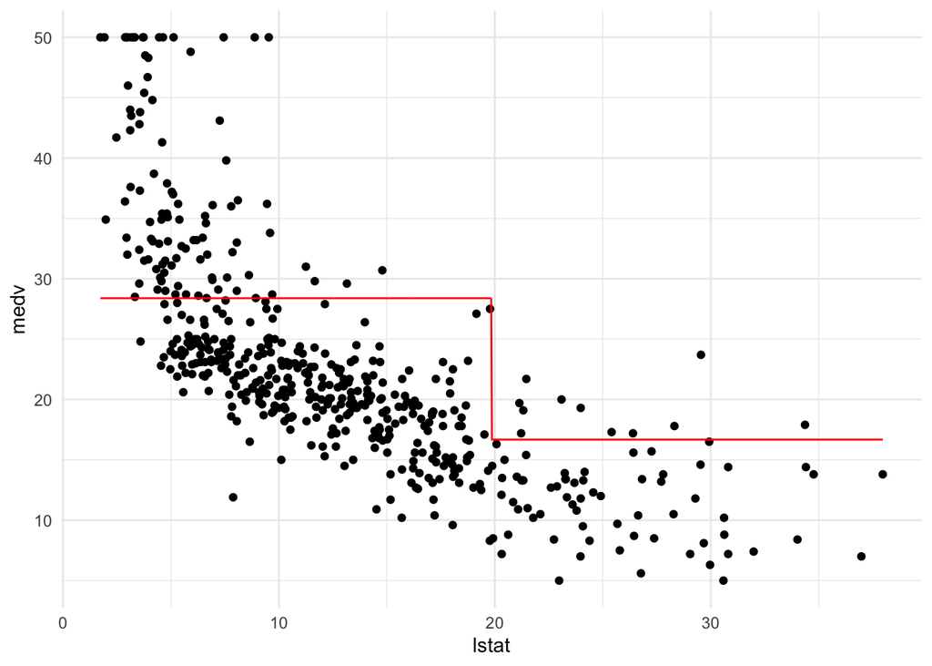

```r
pw2_mod <- lm(medv ~ I(lstat <= median(lstat)), data = Boston)

pred_plot(pw2_mod)
```

```r
coef(pw2_mod)
```

```
##                   (Intercept) I(lstat <= median(lstat))TRUE
##                      16.67747                      11.71067
```

### 7) Adding more cuts to the piecewise regression

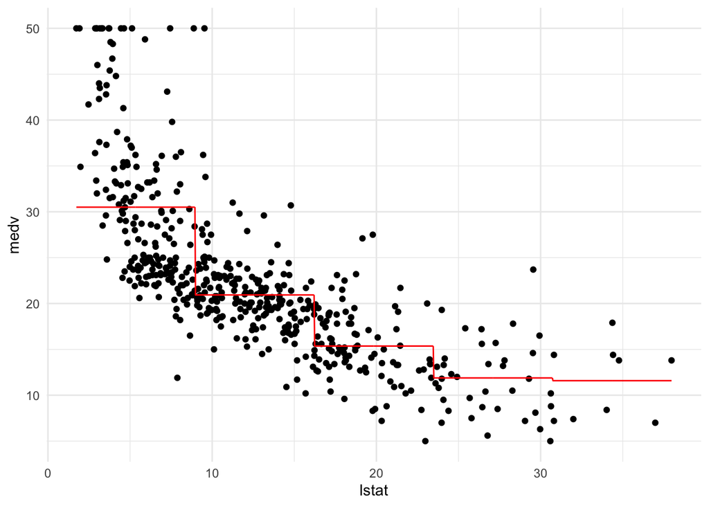

```r
pw5_mod <- lm(medv ~ I(cut(lstat, 5)), data = Boston)

pred_plot(pw5_mod)
```

This is a plot!

### 9) Equal-data piecewise regression

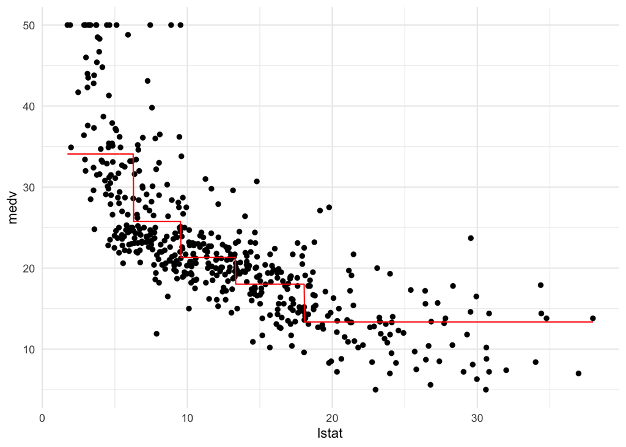

```r
cutvalues <- c(-Inf, quantile(Boston$lstat, probs = c(0.2, 0.4, 0.6, 0.8)), Inf)

pwq_mod <- lm(medv ~ I(cut(lstat, breaks = cutvalues)), data = Boston)

pred_plot(pwq_mod)
```

## Piecewise polynomial regression

### 9) Adding comments

```r
## Create a function that takes two arguments: a vector of values and
## a specified number of knots (by default 1)
piecewise_cubic_basis <- function(vec, knots = 1) {
  ## if the number of specified knots is 0, simply
  ## return the raw cubic polynomial for the whole vector
  if (knots == 0) return(poly(vec, degree = 3, raw = TRUE))

  ## otherwise: cut the vector into knots + 1 intervals
  cut_vec <- cut(vec, breaks = knots + 1)

  ## furthermore, create space for the piecewise cubic based function
  out <- matrix(nrow = length(vec), ncol = 0)

  ## then, we do a for loop for 1 to the number of levels the vector was
  ## cutted into
  for (lvl in levels(cut_vec)) {
    ## and in each loop, create a temporary copy of the intial vector
    tmp <- vec
    ## for all levels which are not currently specified, set the values to 0
    tmp[cut_vec != lvl] <- 0
    ## then the lvl-th column of the earlier created matrix
    ## becomes the raw cubic polynomial of the temporary vector
    out <- cbind(out, poly(tmp, degree = 3, raw = TRUE))
  }
  ## return the matrix that now contains all raw piecewise cubic polynomial
  out
}
```

### 10) Creating piecewise cubic models

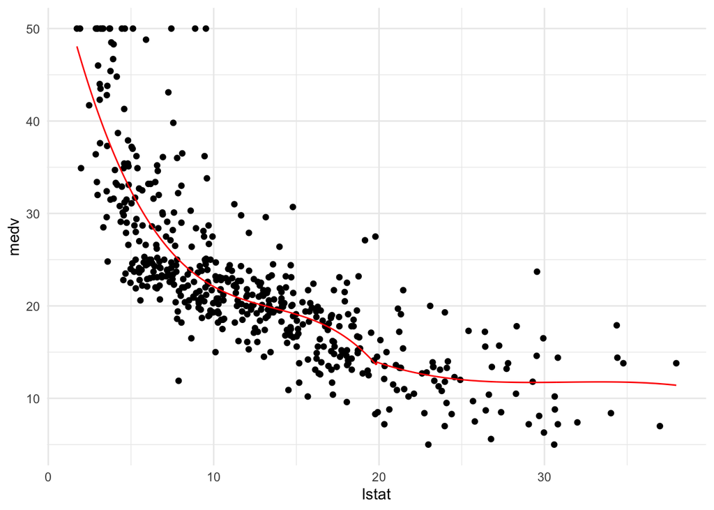

```r
pc1_mod <- lm(medv ~ I(piecewise_cubic_basis(lstat, knots = 1)), data = Boston)
pc2_mod <- lm(medv ~ I(piecewise_cubic_basis(lstat, knots = 2)), data = Boston)
pc3_mod <- lm(medv ~ I(piecewise_cubic_basis(lstat, knots = 3)), data = Boston)

pred_plot(pc1_mod)
```

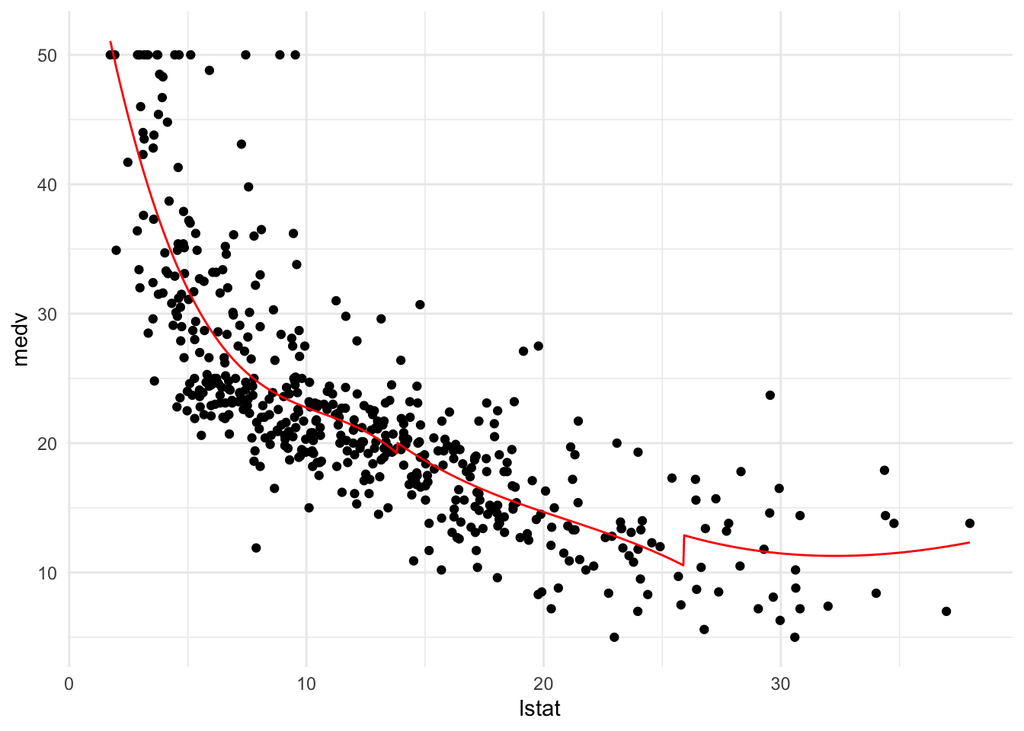

```r
pred_plot(pc2_mod)
```

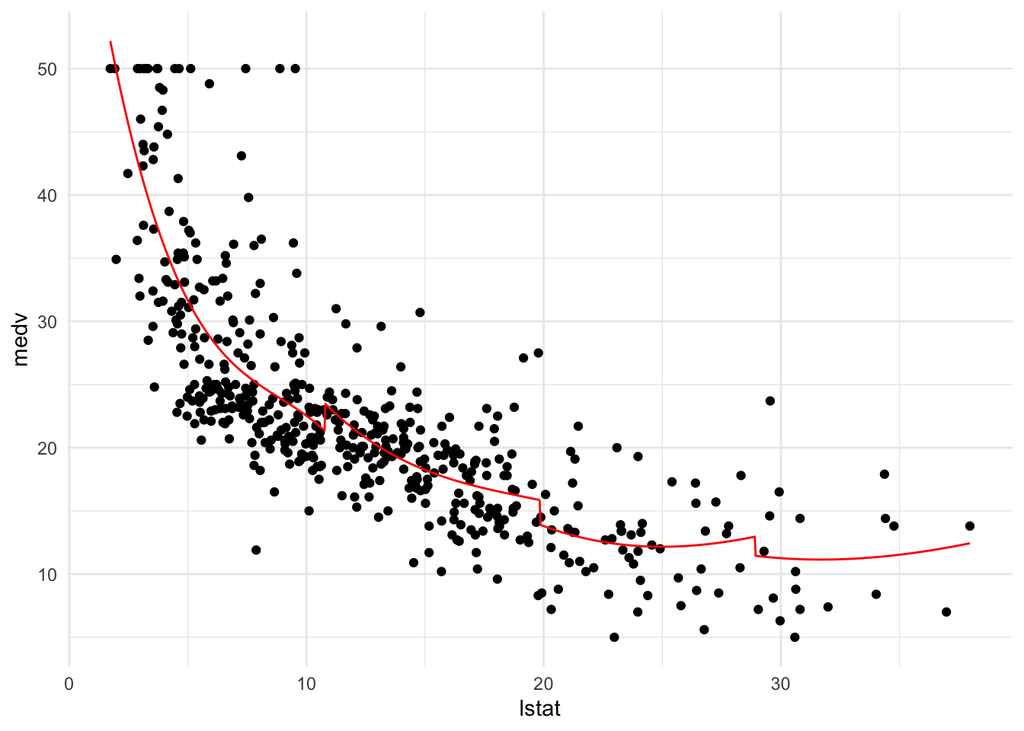

```r
pred_plot(pc3_mod)
```

## Splines

### 11 + 12 + 13) Creating the necessary dataframe

```r
boston_tpb <- select(Boston, medv, lstat) %>%
  mutate(quad_lstat = lstat^2,
         cub_lstat = lstat^3,
         lstat_tpb = ifelse(lstat < median(lstat), 0, (lstat - median(lstat))^3))
```

### 14) Creating a linear model using the above dataframe

```r
tpb_mod <- lm(medv ~ ., data = boston_tpb)

summary(tpb_mod)
```

```
##
## Call:
## lm(formula = medv ~ ., data = boston_tpb)
##
## Residuals:
##      Min       1Q   Median       3Q      Max
## -13.5106  -3.0547  -0.7488   2.1178  27.1383
##
## Coefficients:
##               Estimate Std. Error t value Pr(>|t|)
## (Intercept)  65.514246   3.054303  21.450  < 2e-16 ***
## lstat       -10.324275   1.089886  -9.473  < 2e-16 ***
## quad_lstat    0.856576   0.116108   7.377 6.75e-13 ***
## cub_lstat    -0.025484   0.003810  -6.688 6.05e-11 ***
## lstat_tpb     0.026582   0.004291   6.194 1.22e-09 ***
## ---
## Signif. codes:  0 '***' 0.001 '**' 0.01 '*' 0.05 '.' 0.1 ' ' 1
##
## Residual standard error: 5.206 on 501 degrees of freedom
## Multiple R-squared:  0.6822, Adjusted R-squared:  0.6796
## F-statistic: 268.8 on 4 and 501 DF,  p-value: < 2.2e-16
```

### 15) Using the bs() function

```r
bs1_mod <- lm(medv ~ bs(lstat, degree = 3, knots = median(lstat)), data = Boston)
summary(bs1_mod)
```

```
##
## Call:
## lm(formula = medv ~ bs(lstat, degree = 3, knots = median(lstat)),
##     data = Boston)
##
## Residuals:
##      Min       1Q   Median       3Q      Max
## -13.5106  -3.0547  -0.7488   2.1178  27.1383
##
## Coefficients:
##                                               Estimate Std. Error t value
## (Intercept)                                     50.085      1.549   32.34
## bs(lstat, degree = 3, knots = median(lstat))1  -24.362      2.331  -10.45
## bs(lstat, degree = 3, knots = median(lstat))2  -31.781      1.927  -16.49
## bs(lstat, degree = 3, knots = median(lstat))3  -44.421      3.488  -12.73
## bs(lstat, degree = 3, knots = median(lstat))4  -35.831      3.092  -11.59
##                                               Pr(>|t|)
## (Intercept)                                     <2e-16 ***
## bs(lstat, degree = 3, knots = median(lstat))1   <2e-16 ***
## bs(lstat, degree = 3, knots = median(lstat))2   <2e-16 ***
## bs(lstat, degree = 3, knots = median(lstat))3   <2e-16 ***
## bs(lstat, degree = 3, knots = median(lstat))4   <2e-16 ***
## ---
## Signif. codes:  0 '***' 0.001 '**' 0.01 '*' 0.05 '.' 0.1 ' ' 1
##
## Residual standard error: 5.206 on 501 degrees of freedom
## Multiple R-squared:  0.6822, Adjusted R-squared:  0.6796
## F-statistic: 268.8 on 4 and 501 DF,  p-value: < 2.2e-16
```

### 16) Creating a prediction plot

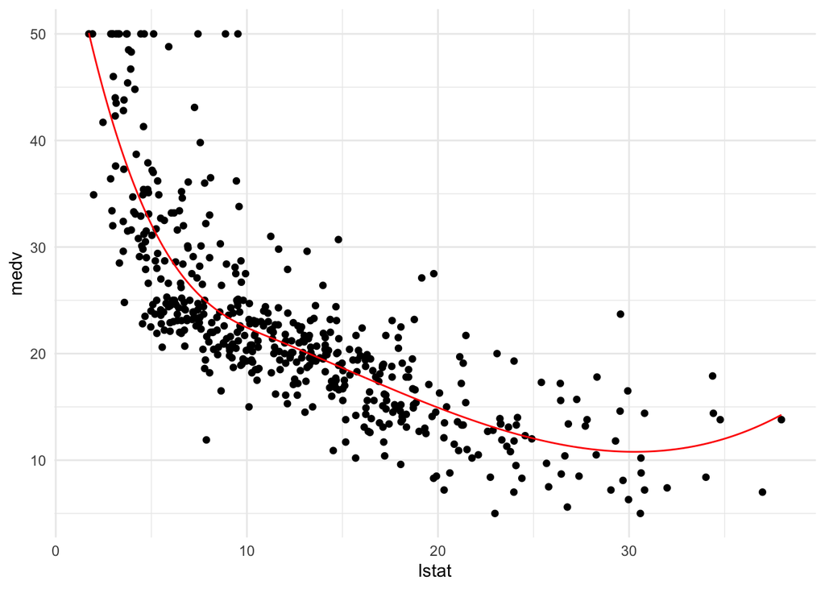

```r
pred_plot(bs1_mod)
```

### 17) Using natural splines instead

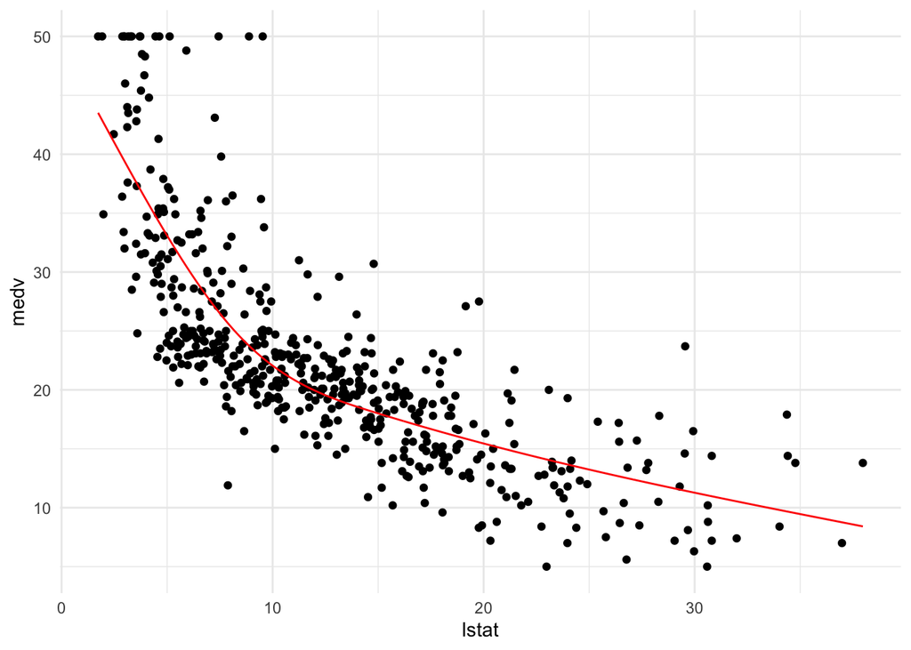

```r
ns3_mod <- lm(medv ~ ns(lstat, df = 3), data = Boston)

pred_plot(ns3_mod)
```

This has a much more natural graph near the end!

### 18) Plotting everything in a grid

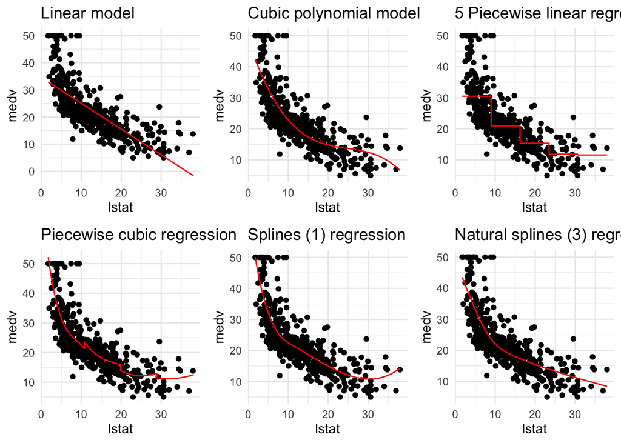

```r
library(cowplot)

plot_grid(pred_plot(lin_mod) + ggtitle("Linear model"), pred_plot(pn3_mod) +
            ggtitle("Cubic polynomial model"),
          pred_plot(pw5_mod) + ggtitle("5 Piecewise linear regression"),
          pred_plot(pc3_mod) + ggtitle("Piecewise cubic regression"),
          pred_plot(bs1_mod) + ggtitle("Splines (1) regression"),
          pred_plot(ns3_mod) + ggtitle("Natural splines (3) regression"))
```

## Programming assignment

```r
mse <- function(y_true, y_pred){
  MSE <- mean((y_true - y_pred)^2, na.rm = TRUE)
  return(MSE)
}

cross_valid <- function(formula, dataset, k){
  require(dplyr)
  ## First, the data should be shuffled,, done in the following way
  dataset <- dataset[sample(nrow(dataset)) ,]
  ## Then, the dataset should have an indicator variable for k subsamples
  dataset <- dataset %>%
    mutate(., fold = cut(1:nrow(dataset), breaks = k,
                                labels = 1:k))
  ## Create space for the mse values
  mse <- rep(NA, k)
  ## We want the function to calculate the mse k times, so we use a for loop
  ## In each loop:
  for(i in 1:k){
    ## First, we split the dataset in a training and validation set
    train_data <- dataset %>% filter(fold != i)
    valid_data <- dataset %>% filter(fold == i)

    ## Then, we train the model in the training set
    test_lm <- lm(formula = formula, data = train_data)

    ## Then, we get the outcome name (this was taken from your code)
    outcome_name <- as.character(formula)[2]

    ## Finally, we calculate the mse value using the trained set on our
    ## validation set and put this in the ith element
    mse[i] <- mse(valid_data[[outcome_name]],
                  predict(test_lm, newdata = valid_data))
  }
  ## Finally, we calculate the mean of all mses and return this value
  M_MSE <- mean(mse)
  return(M_MSE)
}

mean_MSE <- cbind(c("lin", "pn3", "pc3", "bs1", "ns3"),
                  rep(NA, 5))


mean_MSE[1,2] <- cross_valid(formula = lin_mod$call[[2]], dataset = Boston, k = 12)
mean_MSE[2,2] <- cross_valid(formula = pn3_mod$call[[2]], dataset = Boston, k = 12)
mean_MSE[3,2] <- cross_valid(formula = pc3_mod$call[[2]], dataset = Boston, k = 12)
mean_MSE[4,2] <- cross_valid(formula = bs1_mod$call[[2]], dataset = Boston, k = 12)
mean_MSE[5,2] <- cross_valid(formula = ns3_mod$call[[2]], dataset = Boston, k = 12)

mean_MSE
```

```
##      [,1]  [,2]
## [1,] "lin" "38.8693504755676"
## [2,] "pn3" "29.5281834881561"
## [3,] "pc3" "28.4945818744706"
## [4,] "bs1" "27.2919731368607"
## [5,] "ns3" "28.8520500584185"
```

We find that the bs1 model has the lowest out of sample mean squared error! Awesome.